# Lab 08: Heteroskedasticity

EE509

## Objectives

In this lab we’re going to:

- Explore putting process models on variances (heteroskedasticity)
- Explore Bayesian model selection

# Tasks

### Load & Plot Data

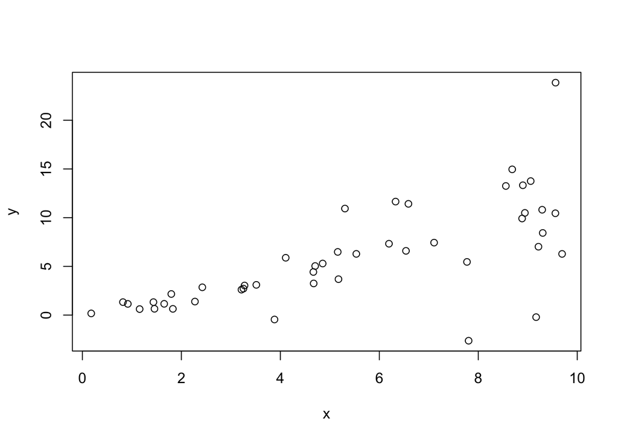

```r
load("data/Lab08_het.RData")
plot(x,y)
```

# Fit traditional linear model

Start from the basic linear model from lab 5. Fit the model to the data, perform you standard set of Bayesian metrics [trace plots, densities, GBR, pairs, effective sample size, etc.], and plot the resulting model (CI and PI) and data. When simulating your PI, make sure you’ve got the residual error in the right units (precision vs SD)

```r
univariate_regression <- "
model{

  b ~ dmnorm(b0,Vb)     ## multivariate Normal prior on vector of regression params
  S ~ dgamma(s1,s2)    ## prior precision

  for(i in 1:n){
      mu[i] <- b[1] + b[2]*x[i]     ## process model
      y[i]  ~ dnorm(mu[i],S)                ## data model
    like[i] <- dnorm(y[i],mu[i],S)  # likelihood (added for tasks below)
  }
}
"

data <- list(x = x, y = y, n = length(y),
             b0 = as.vector(c(0,0)),   ## regression b mean priors
             Vb = solve(diag(10000,2)),   ## regression b precision priors
             s1 = 0.1,                    ## error prior n/2
             s2 = 0.1)                    ## error prior SS/2

## initial conditions
inits <- list()
for(i in 1:3){
 inits[[i]] <- list(b = rnorm(2,0,5), S = runif(1,1/200,1/20))}

j.model   <- jags.model (file = textConnection(univariate_regression),
                             data = data,
                             inits = inits,
                             n.chains = 3)
jags.out   <- coda.samples (model = j.model,
                            variable.names = c("b","S"),
                                n.iter = 5000)
```

Check diagnostics:

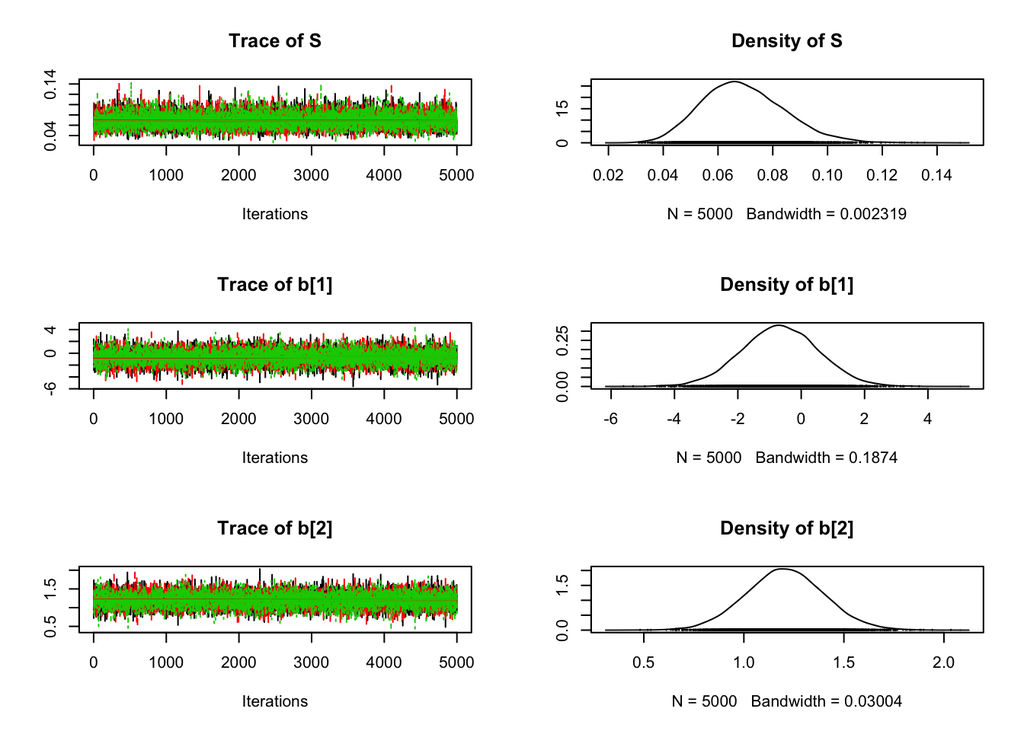

```r
plot(jags.out) ## fuzzy caterpillars - good
```

```r
gelman.diag(jags.out) ## values equal 1 - good
```

```
## Potential scale reduction factors:
##
##      Point est. Upper C.I.
## S             1          1
## b[1]          1          1
## b[2]          1          1
##
## Multivariate psrf
##
## 1
```

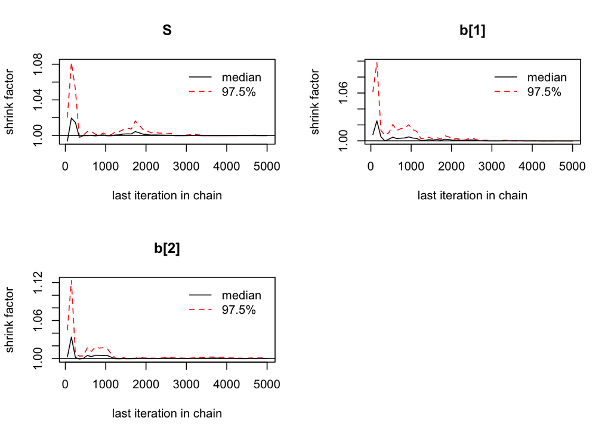

```r
GBR <- gelman.plot(jags.out) ## determine convergence
```